# CUSTOMER BEHAVIOUR - Classification2 Analysis

Tubagus Fathul Arifin

2022-10-19

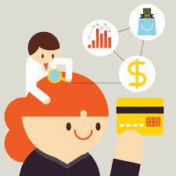

# **1. DATA INTRODUCTION**

As a marketing analyst, we want to increase sales by targeting customers with certain characteristics. From the historical data of **400 customers** who have been prospected, we get information about gender, age, and salary category as well as whether he bought our product or not.

## **1.1. Data Preparation**

Read the data.

```r
CB <- read.csv("Customer_Behaviour.csv")
CB
```

| Gender | Age | Salary | Purchased |
| --- | --- | --- | --- |
| Male | < 30 | Low | No |
| Male | 30-50 | Low | No |
| Female | < 30 | Medium | No |
| Female | < 30 | Medium | No |
| Male | < 30 | Medium | No |
| Male | < 30 | Medium | No |
| Female | < 30 | Medium | No |
| Female | 30-50 | High | Yes |
| Male | < 30 | Low | No |
| Female | 30-50 | Medium | No |

[output cut: 390 more lines]

```r
glimpse(CB)
```

```
## Rows: 400
## Columns: 4
## $ Gender    <chr> "Male", "Male", "Female", "Female", "Male", "Male", "Female"…
## $ Age       <chr> "< 30", "30-50", "< 30", "< 30", "< 30", "< 30", "< 30", "30…
## $ Salary    <chr> "Low", "Low", "Medium", "Medium", "Medium", "Medium", "Mediu…
## $ Purchased <chr> "No", "No", "No", "No", "No", "No", "No", "Yes", "No", "No",…
```

- **Gender**: Gender (Male, Female)
- **Age**: Age range (< 30, 30-50, > 50)
- **Salary**: Customer Salary Category (Low, Medium, High)
- **Purchased**: Whether the client buys our product or not (Yes, No)

Check Missing Value.

```r
anyNA(CB)
```

```
## [1] FALSE
```

```r
colSums(is.na(CB))
```

```
##    Gender       Age    Salary Purchased
##         0         0         0         0
```

## **1.2. Data Preprocessing**

We need to change the data type of each variable to a data type that matches the data.

```r
CB <- CB %>%
  mutate(Gender = as.factor(Gender),
         Age = as.factor(Age),
         Salary = as.factor(Salary),
         Purchased = as.factor(Purchased))
CB
```

| Gender | Age | Salary | Purchased |
| --- | --- | --- | --- |
| Male | < 30 | Low | No |
| Male | 30-50 | Low | No |
| Female | < 30 | Medium | No |
| Female | < 30 | Medium | No |
| Male | < 30 | Medium | No |
| Male | < 30 | Medium | No |
| Female | < 30 | Medium | No |
| Female | 30-50 | High | Yes |
| Male | < 30 | Low | No |
| Female | 30-50 | Medium | No |

[output cut: 390 more lines]

```r
glimpse(CB)
```

```
## Rows: 400
## Columns: 4
## $ Gender    <fct> Male, Male, Female, Female, Male, Male, Female, Female, Male…
## $ Age       <fct> < 30, 30-50, < 30, < 30, < 30, < 30, < 30, 30-50, < 30, 30-5…
## $ Salary    <fct> Low, Low, Medium, Medium, Medium, Medium, Medium, High, Low,…
## $ Purchased <fct> No, No, No, No, No, No, No, Yes, No, No, No, No, No, No, No,…
```

# **2. DATA ANALYSIS**

## **2.1. Exploratory**

From the busines question, We are going to build a predictive model to classify *“whether the client buys our product or not”* (`Purchased` = Yes / No).

```r
levels(CB$Purchased)
```

```
## [1] "No"  "Yes"
```

From the level above, it can be seen that the target variable consists of two categories, namely “No” and “Yes”.

Check the distribution proportion of **target class**

```r
prop.table(table(CB$Purchased))
```

```
##
##     No    Yes
## 0.6425 0.3575
```

```r
table(CB$Purchased)
```

```
##
##  No Yes
## 257 143
```

When viewed from the proportion of the two classes, it is quite balanced, so we don’t really need additional pre-processing to balance the proportion between the two target classes of variables.

## **2.2. Cross Validation**

Splitting the data into data train(85%) and data test(15%).

```r
RNGkind(sample.kind = "Rounding")
set.seed(417)

# index sampling
index <- sample(x = nrow(CB), size = nrow(CB)*0.85)

# splitting
CB_train <- CB[index , ]

CB_test <- CB[-index , ]
```

Check dimension.

```r
dim(CB_train)
```

```
## [1] 340   4
```

```r
dim(CB_test)
```

```
## [1] 60  4
```

Eliminating target variable from test dataset.

```r
CB_test_Val <- CB_test %>% select(-Purchased)
dim(CB_test_Val)
```

```
## [1] 60  3
```

Check the distribution proportion of **target class** from data train.

```r
prop.table(table(CB_train$Purchased))
```

```
##
##   No  Yes
## 0.65 0.35
```

```r
table(CB_train$Purchase)
```

```
##
##  No Yes
## 221 119
```

The proportion is quite balanced.

# **3. NAIVE BAYES MODEL**

## **3.1. Build the model**

**Skewness Due To Scarcity** is one of the characteristics of Naive Bayes Model. To get over it, we will do a **Laplace Smoothing** when we build the model.

```r
naive_model <- naiveBayes(Purchased  ~ .,
                          data = CB_train,
                          laplace = 1)
naive_model
```

```
##
## Naive Bayes Classifier for Discrete Predictors
##
## Call:
## naiveBayes.default(x = X, y = Y, laplace = laplace)
##
## A-priori probabilities:
## Y
##   No  Yes
## 0.65 0.35
##
## Conditional probabilities:
##      Gender
## Y        Female      Male
##   No  0.4887892 0.5112108
##   Yes 0.5454545 0.4545455
##
##      Age
## Y           < 30       > 50      30-50
##   No  0.37946429 0.01785714 0.60267857
##   Yes 0.01639344 0.30327869 0.68032787
##
##      Salary
## Y           High        Low     Medium
##   No  0.08482143 0.20982143 0.70535714
##   Yes 0.52459016 0.25409836 0.22131148
```

## **3.2. Predict the model with test data set**

```r
naive_pred <- predict(naive_model, newdata = CB_test_Val)
naive_pred
```

```
##  [1] No  No  No  No  No  No  No  Yes No  No  No  Yes No  No  No  No  No  Yes No
## [20] No  No  No  No  No  No  No  No  No  No  No  No  No  No  No  No  No  No  Yes
## [39] Yes Yes Yes No  Yes Yes Yes No  No  No  Yes Yes Yes No  Yes No  Yes Yes No
## [58] No  Yes No
## Levels: No Yes
```

## **3.3. Confussion Matrix**

```r
(conf_mat_naive <- table(naive_pred, CB_test$Purchased))
```

```
##
## naive_pred No Yes
##        No  34   9
##        Yes  2  15
```

The results of the confusionmatrix shows that the Naive Bayes classification correctly predicted **15** customers will **buy** and **2 incorrect** predictions. Similarly, the model predicts **34** customers will **not buy** and **9 predictions incorrectly**. What is the level of accuracy?? Let’s see below.

```r
(nb_cm <- confusionMatrix(conf_mat_naive))
```

```
## Confusion Matrix and Statistics
##
##
## naive_pred No Yes
##        No  34   9
##        Yes  2  15
##
##                Accuracy : 0.8167
##                  95% CI : (0.6956, 0.9048)
##     No Information Rate : 0.6
##     P-Value [Acc > NIR] : 0.0002826
##
##                   Kappa : 0.5985
##
##  Mcnemar's Test P-Value : 0.0704404
##
##             Sensitivity : 0.9444
##             Specificity : 0.6250
##          Pos Pred Value : 0.7907
##          Neg Pred Value : 0.8824
##              Prevalence : 0.6000
##          Detection Rate : 0.5667
##    Detection Prevalence : 0.7167
##       Balanced Accuracy : 0.7847
##
##        'Positive' Class : No
##
```

# **4. DECISSION TREE MODEL**

## **4.1. Build the model.**

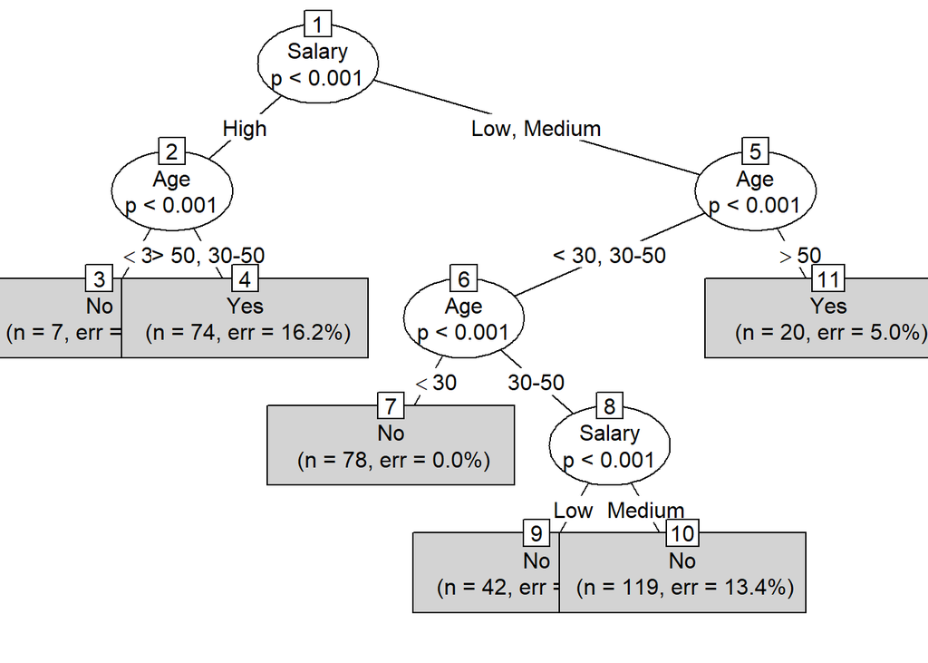

```r
dt_model <- ctree(Purchased ~ .,
                  CB_train,
                  control = ctree_control(mincriterion=0.95,
                                             minsplit=20,
                                             minbucket=7))
plot(dt_model, type="simple")
```

```r
dt_model
```

```
##
## Model formula:
## Purchased ~ Gender + Age + Salary
##
## Fitted party:
## [1] root
## |   [2] Salary in High
## |   |   [3] Age < 30: No (n = 7, err = 14.3%)
## |   |   [4] Age > 50, 30-50: Yes (n = 74, err = 16.2%)
## |   [5] Salary in Low, Medium
## |   |   [6] Age < 30, 30-50
## |   |   |   [7] Age < 30: No (n = 78, err = 0.0%)
## |   |   |   [8] Age in 30-50
## |   |   |   |   [9] Salary in Low: No (n = 42, err = 50.0%)
## |   |   |   |   [10] Salary in Medium: No (n = 119, err = 13.4%)
## |   |   [11] Age > 50: Yes (n = 20, err = 5.0%)
##
## Number of inner nodes:    5
## Number of terminal nodes: 6
```

the model above is built with default parameters. And to produce a better model we need to do *post-prunning tree* to get a simpler model. Becaude for a **Decission Tree Model** it has a better result if the model is simpler.

And to do that We will changing the following parameters:

- `mincriterion`: increase the value
- `minsplit`: increase the value
- `minbucket`: increase the value

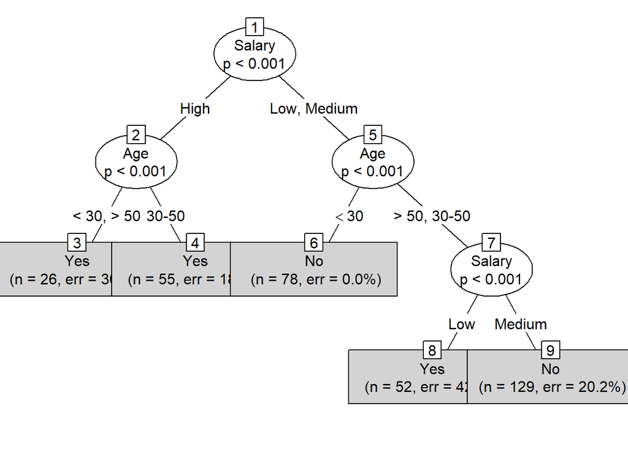

```r
dt_model_prun <- ctree(Purchased ~ .,
                  CB_train,
                  control = ctree_control(mincriterion=0.97,
                                             minsplit=60,
                                             minbucket=21))
plot(dt_model_prun, type="simple")
```

```r
dt_model_prun
```

```
##
## Model formula:
## Purchased ~ Gender + Age + Salary
##
## Fitted party:
## [1] root
## |   [2] Salary in High
## |   |   [3] Age < 30, > 50: Yes (n = 26, err = 30.8%)
## |   |   [4] Age in 30-50: Yes (n = 55, err = 18.2%)
## |   [5] Salary in Low, Medium
## |   |   [6] Age < 30: No (n = 78, err = 0.0%)
## |   |   [7] Age > 50, 30-50
## |   |   |   [8] Salary in Low: Yes (n = 52, err = 42.3%)
## |   |   |   [9] Salary in Medium: No (n = 129, err = 20.2%)
##
## Number of inner nodes:    4
## Number of terminal nodes: 5
```

From the result above, the model has become simple enough.

## **4.2. Predict the model with test data set**

After we train the data train then we can use it directly on the test data.

```r
dt_pred <- predict(dt_model, CB_test)
dt_pred
```

```
##   4  12  19  23  25  30  32  43  47  48  61  65  73  90  94  98 102 104 105 118
##  No  No  No  No  No  No  No Yes  No  No  No Yes  No  No  No  No  No Yes  No  No
## 126 128 129 145 165 167 168 169 174 177 181 184 218 226 232 238 247 248 275 279
##  No  No  No  No  No  No  No  No  No  No  No  No  No  No  No  No  No Yes Yes Yes
## 293 295 300 303 312 313 323 327 329 332 341 344 348 352 357 362 373 379 380 392
## Yes  No Yes Yes Yes  No  No  No Yes Yes Yes  No Yes  No Yes Yes  No  No Yes  No
## Levels: No Yes
```

## **4.3. Confussion Matrix**

```r
(conf_matrix_dt <- table(dt_pred, CB_test$Purchased))
```

```
##
## dt_pred No Yes
##     No  34   9
##     Yes  2  15
```

The results of the confusionmatrix shows that the Decission Tree classification correctly predicted **15** customers will **buy** and **2 incorrect** predictions. Similarly, the model predicts **34** customers will **not buy** and **9 predictions incorrectly**. What is the level of accuracy?? Let’s see below.

```r
(dt_cm <- confusionMatrix(conf_matrix_dt))
```

```
## Confusion Matrix and Statistics
##
##
## dt_pred No Yes
##     No  34   9
##     Yes  2  15
##
##                Accuracy : 0.8167
##                  95% CI : (0.6956, 0.9048)
##     No Information Rate : 0.6
##     P-Value [Acc > NIR] : 0.0002826
##
##                   Kappa : 0.5985
##
##  Mcnemar's Test P-Value : 0.0704404
##
##             Sensitivity : 0.9444
##             Specificity : 0.6250
##          Pos Pred Value : 0.7907
##          Neg Pred Value : 0.8824
##              Prevalence : 0.6000
##          Detection Rate : 0.5667
##    Detection Prevalence : 0.7167
##       Balanced Accuracy : 0.7847
##
##        'Positive' Class : No
##
```

# **5. RANDOM FOREST MODEL**

When using random forest - we are not required to split our dataset into train and test sets because random forest already has **out-of-bag estimates (OOB)** which act as a reliable estimate of the accuracy on unseen examples. Although, it is also possible to hold out a regular train-test cross-validation.

## **5.1. Build the model**

We will create a Random Forest model using a train dataset with 5-fold cross validation, then the process is repeated 3 times.

```r
set.seed(417)

ctrl <- trainControl(method = "repeatedcv",
                     number = 5, # k-fold
                     repeats = 3) # repetition

(CB_forest <- train(Purchased ~ .,
                   data = CB_train,
                   method = "rf", # random forest
                    trControl = ctrl))
```

```
## Random Forest
##
## 340 samples
##   3 predictor
##   2 classes: 'No', 'Yes'
##
## No pre-processing
## Resampling: Cross-Validated (5 fold, repeated 3 times)
## Summary of sample sizes: 272, 272, 272, 271, 273, 272, ...
## Resampling results across tuning parameters:
##
##   mtry  Accuracy   Kappa
##   2     0.8283868  0.6181232
##   3     0.8303476  0.6237286
##   5     0.8273918  0.6174792
##
## Accuracy was used to select the optimal model using the largest value.
## The final value used for the model was mtry = 3.
```

```r
saveRDS(CB_forest, "CB_forest.RDS")
```

From the model summary, we know that the optimum number of variables considered for splitting at each tree node is 3. We can also inspect the importance of each variable that was used in our random forest using `varImp()`.

```r
varImp(CB_forest)
```

```
## rf variable importance
##
##              Overall
## SalaryMedium  100.00
## Age> 50        82.73
## Age30-50       32.63
## SalaryLow      20.59
## GenderMale      0.00
```

The OOB we achieved (in the summary below) was generated from our CB_train dataset.

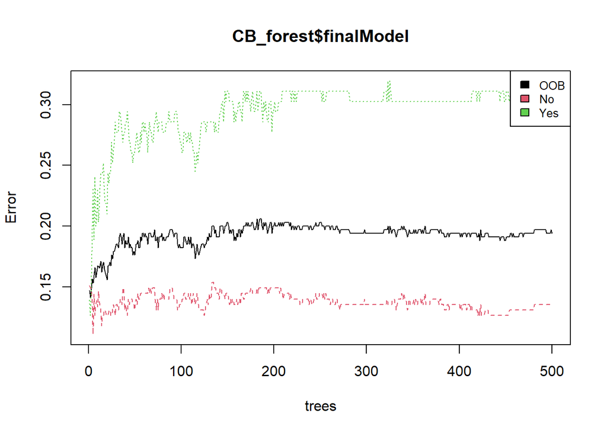

```r
plot(CB_forest$finalModel)
legend("topright", colnames(CB_forest$finalModel$err.rate),col=1:6,cex=0.8,fill=1:6)
```

And we can see the final model as follows.

```r
CB_forest$finalModel
```

```
##
## Call:
##  randomForest(x = x, y = y, mtry = param$mtry)
##                Type of random forest: classification
##                      Number of trees: 500
## No. of variables tried at each split: 3
##
##         OOB estimate of  error rate: 19.41%
## Confusion matrix:
##      No Yes class.error
## No  191  30   0.1357466
## Yes  36  83   0.3025210
```

## **5.2. Predict the model with test data set**

Let’s test our random forest model to our CB_test dataset.

```r
forest_pred <- predict(CB_forest, CB_test_Val)
forest_pred
```

```
##  [1] No  No  No  No  No  No  No  Yes No  No  No  Yes No  No  No  No  No  Yes No
## [20] No  No  No  No  Yes No  No  No  No  No  No  No  No  No  No  No  No  No  Yes
## [39] Yes Yes Yes No  Yes Yes Yes No  No  No  Yes Yes Yes No  Yes No  Yes Yes No
## [58] No  Yes No
## Levels: No Yes
```

## **5.3. Confussion Matrix**

```r
(conf_matrix_forest <- table(forest_pred, CB_test$Purchased))
```

```
##
## forest_pred No Yes
##         No  33   9
##         Yes  3  15
```

The results of the confusionmatrix shows that the Random Forest classification correctly predicted **15** customers will **buy** and **3 incorrect** predictions. Similarly, the model predicts **33** customers will **not buy** and **9 predictions incorrectly**. What is the level of accuracy?? Let’s see below.

```r
(rf_cm <- confusionMatrix(conf_matrix_forest))
```

```
## Confusion Matrix and Statistics
##
##
## forest_pred No Yes
##         No  33   9
##         Yes  3  15
##
##                Accuracy : 0.8
##                  95% CI : (0.6767, 0.8922)
##     No Information Rate : 0.6
##     P-Value [Acc > NIR] : 0.0008097
##
##                   Kappa : 0.5652
##
##  Mcnemar's Test P-Value : 0.1489147
##
##             Sensitivity : 0.9167
##             Specificity : 0.6250
##          Pos Pred Value : 0.7857
##          Neg Pred Value : 0.8333
##              Prevalence : 0.6000
##          Detection Rate : 0.5500
##    Detection Prevalence : 0.7000
##       Balanced Accuracy : 0.7708
##
##        'Positive' Class : No
##
```

# **6. CONCLUSION**

Based on business questions, the best metrics are `accuracy` & `sensitivity/recall`. Because we want to predict whether a customer will buy or not the product.

```r
(eval_nb <- data_frame(Accuracy = nb_cm$overall[1],
           Recall = nb_cm$byClass[1],
           Specificity = nb_cm$byClass[2],
           Precision = nb_cm$byClass[3]))
```

| Accuracy | Recall | Specificity | Precision |
| --- | --- | --- | --- |
| 0.8166667 | 0.9444444 | 0.625 | 0.7906977 |

```r
(eval_dt <- data_frame(Accuracy = dt_cm$overall[1],
           Recall = dt_cm$byClass[1],
           Specificity = dt_cm$byClass[2],
           Precision = dt_cm$byClass[3]))
```

| Accuracy | Recall | Specificity | Precision |
| --- | --- | --- | --- |
| 0.8166667 | 0.9444444 | 0.625 | 0.7906977 |

```r
(eval_rf <- data_frame(Accuracy = rf_cm$overall[1],
           Recall = rf_cm$byClass[1],
           Specificity = rf_cm$byClass[2],
           Precision = rf_cm$byClass[3]))
```

| Accuracy | Recall | Specificity | Precision |
| --- | --- | --- | --- |
| 0.8 | 0.9166667 | 0.625 | 0.7857143 |

Based on the evaluation above, it can be seen that the results of the Naive Bayes & Decission Tree have a similar and better accuracy and sensitivity/recal than Random Forest.

So it was decided that we can use Naive Bayes & Decission Tree model to answer future business questions.